# HydraR: Agentic Infrastructure for Reproducible Scientific Research

Author

Chi Nam (Ignatius) Pang, Aidan Tay

Published

2026-05-01

# 1 Executive Summary

Large Language Models (LLMs) are catalyzing a paradigm shift in scientific computing, with simple chatbots evolving into autonomous “agents” that can plan and execute complex tasks, and powerful multi-agent systems that collaborate to solve multi-faceted problems. This transformation holds immense potential for data science fields like bioinformatics, where such systems can automate workflows that previously demanded extensive computational expertise. Despite this, the R ecosystem currently lacks the necessary infrastructure to define, run, and share agentic workflows in a way that is reproducible and safe in practice. While our HydraR package provides a foundational proof-of-concept for orchestrating AI agents in R, significant development is needed to transform it into a robust framework capable of supporting the reliable workflows required by the broader scientific community.

In this project, we address this need by extending on the core components of HydraR. Specifically, to enable reproducible and secure agentic orchestration, we will pursue two distinct objectives. First, we aim to develop a comprehensive memory and state management system that incorporates features including automated retries, execution caching, and output validation to enhance workflow resilience and reduce redundant computations. Second, we aim to develop a robust environment management system that integrates with isolation tools such as Git worktree and Docker, ensuring agents can execute safely within sensitive research environments. By delivering these capabilities, this project will transform HydraR into a flexible, agent-agnostic framework that empowers computational biologists to confidently define, run, and share agentic workflows, thereby upholding the rigor and reproducibility of R-based scientific research.

## 1.1 Budget

We request **$14,400 USD** in funding for an expert software developer to work on this project over a 7-week period (approximately 245 hours).

# 2 Signatories

## 2.1 Project Team

- **Chi Nam (Ignatius) Pang** - **Co-Primary Investigator**. Senior Bioinformatician at Macquarie University / Australian Proteome Analysis Facility (APAF). Expert in R package development, proteomics pipelines, and reproducibility standards.
- **Aidan Tay** - **Co-Primary Investigator**. Bioinformatician at APAF. Architect of the HydraR R6 DAG engine, Git worktree isolation logic, and the custom state-hashing persistence Layer.

## 2.2 Contributors

- **APAF Bioinformatics Team**: Provided the testing ground for initial prototypes in high-throughput proteomics and metabolomics research.
- **Antigravity AI**: Agentic assistant used during the rapid prototyping and documentation hardening phase of the project (as disclosed in `agents.md`).

## 2.3 Community Supporters

- **Hanna Szafranska**: PhD student at University of Cambridge.
- **Nathalie Nataren**: PhD Student at Adelaide University.
- **Tyrone Chen**: Bioinformatician at Peter MacCallum Cancer Centre.
- **Calum Walsh**: Bioinformatician at University of Melbourne.
- **Johan Gustafsson**: Research Community Engagement Lead at Australian BioCommons.

## 2.4 Consulted

- **rOpenSci Editorial Board**: Initial discussions regarding HydraR’s role in the AI-R ecosystem.
- **Macquarie University**: Consulted on the impact of agentic orchestration for national-scale omics infrastructure.
- **Ben Goudey**: AI Technical Lead at Australian BioCommons.
- **Henrik Bengtsson**: Consulted on HydraR package design and package infrastructure.
- **Jeroen Ooms**: Consulted on HydraR package design and package infrastructure.

# 3 The Problem

Large Language Models (LLMs) are catalyzing a paradigm shift in scientific computing, fundamentally transforming how research is performed. This transformation is particularly evident in the field of bioinformatics, where LLMs have evolved beyond simple chatbots into autonomous “agents” that can plan and execute complex tasks previously requiring computational expertise, and into powerful multi-agent systems where a team of AI agents can autonomously collaborate to tackle multi-faceted problems. By democratizing access to these sophisticated multi-agent systems, this automation not only empowers the broader scientific community to harness high-performance workflows once restricted to deep domain specialists but also accelerates biological discovery.

Yet despite offering many great benefits, **the current R ecosystem lacks the necessary framework for traceable, stateful, and secure agent orchestration**. R packages like `ellmer` and `mall` provide excellent interfaces but fail to record agent decisions, making the process ephemeral and untraceable. Meanwhile, advanced frameworks such as `LangGraph` and `AutoGen` in the Python ecosystem lack the necessary features for auditable agent orchestration, rendering them unsuitable for R-based research via Python-based bridges (i.e., `reticulate`). Moreover, granting autonomous agents unchecked access to research environments can inadvertently lead to unwanted file modifications, deletions, or corruption of the working directory. While packages such as `LLMagentR` and `puppeteeR` enable multi-agent orchestration and state management, `puppeteeR` lacks restart from checkpoint capabilities and both `LLMagentR` and `puppeteeR` do not implement environment isolation for agents. Thus, to safeguard the integrity of R-based research, a robust framework must exist to support the development and reproducible use of agentic systems.

To bridge the gap in the R ecosystem, we developed HydraR, an R package dedicated to the scientific reproducibility of agentic systems. **Although HydraR provides the foundational proof-of-concept for orchestrating AI agents in R, significant development is needed to transform it into a framework capable of supporting the reliable workflows required by the broader scientific community**. Specifically, this project will build on HydraR and aims to develop:

1. A comprehensive memory and state management system for logging ephemeral agent reasoning and agent interactions.
2. A robust environment management system for isolating agents from the host environment.

By delivering these systems, **we will equip computational biologists with the necessary tools to develop production-grade agentic systems**, such as automated retries of failed tasks, execution caching for reducing redundant computations, and safe execution of agents without risking the integrity of sensitive research environments. Crucially, **developing these tools will transform HydraR into a flexible, agent-agnostic framework compatible with any orchestration package**, and therefore an infrastructure hub for the next generation of agentic tools. By serving as the central foundation for traceable, stateful, and secure agent orchestration, HydraR will empower computational biologists and R developers alike to adopt agentic systems with confidence, enabling them to build reproducible AI-driven workflows that uphold the rigorous standards of scientific research.

# 4 The Proposal

## 4.1 Overview

This project addresses the critical need for traceable, stateful, and secure agent orchestration in R by building upon HydraR (https://github.com/APAF-bioinformatics/HydraR), a package dedicated to the reproducibility of agentic systems. Specifically, **we aim to develop a comprehensive memory and state management system for logging ephemeral agent reasoning and agent interactions, and a robust environment management system for isolating agents from the host environment**. These systems will equip computational biologists with the tools to develop production-grade agentic systems, by enabling automated retries, reducing redundant computations, and safe execution within sensitive research environments. By developing these tools, HydraR will become a flexible, agent-agnostic framework compatible with any orchestration package, transforming HydraR into an infrastructure hub for the next generation of agentic tools.

## 4.2 Details

To bridge the gap in the R ecosystem and deliver a robust framework for traceable, stateful and secure agent orchestration, this project will leverage the existing functionality of HydraR. Specifically, we aim to address this critical need through two objectives:

### 4.2.1 Objective 1: Memory and State Management

#### 4.2.1.1 Aim

To develop a comprehensive memory and state management system for logging ephemeral agent reasoning and agent interactions.

#### 4.2.1.2 Rationale

Agent memory is often ephemeral and untraceable, making it difficult to capture and audit the entire “journey” of an agentic workflow. While HydraR uses DuckDB for continuous checkpointing and verifiable records, **it currently lacks specialized features required for production-grade bioinformatic pipelines**, such as automated retries, execution caching, and validation of agent outputs for workflow resilience.

#### 4.2.1.3 Approach

To develop a comprehensive memory and state management system, we will introduce several enhancements to HydraR:

- **Restart Checkpointing**: We will implement a system to automatically serialize agents, environment, local variables, and their current reasoning state. In the event of a failure (e.g., API timeout, resource exhaustion, or logic error), HydraR can reconstitute the exact state of the R session, allowing for automated retries without restarting the entire pipeline.
- **Execution Caching and State Retrieval**: We will implement a content-addressable storage (CAS) model for all agent-generated artifacts. By hashing output files and R objects, and linking them to specific reasoning paths, HydraR can maintain a complete audit trail of how each artifact was generated, allowing the system to “skip” redundant tasks and “resume” workflows from any saved state.
- **Agent Validation and Recovery**: We will implement a system to automatically validate agent outputs. If the output of an agent fails to validate (e.g., malformed code or incorrect data schema), HydraR can diagnose and rectify the error, ensuring the main research flow continues safely and autonomously.

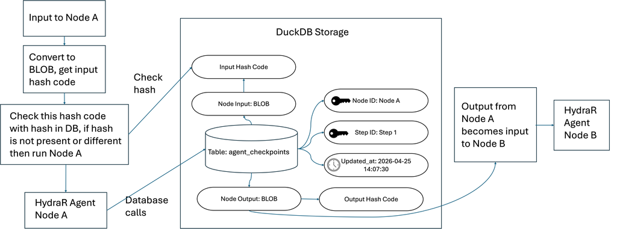

Memory and State Management

### 4.2.2 Objective 2: Environment Management

#### 4.2.2.1 Aim

To develop a robust environment management system for isolating agents from the host environment.

#### 4.2.2.2 Rationale

Granting autonomous agents unchecked agent access to research environments risks unintended file modifications, deletions, or corruption of the working directory. Unrestricted access to the working directory also makes it difficult for parallelised agents to work on the same task without overwriting each other’s work, hindering scalability and interoperability. While HydraR employs a prototype Git worktree layer to track file modifications and prevent parallel agents from overwriting data, **this capability must be adapted for containerized execution to enable more scalable and interoperable agent workflows**.

#### 4.2.2.3 Approach

To develop a robust environment management system, we will introduce several new capabilities to HydraR:

- **Docker Integration**: We will implement a Docker layer as the primary mechanism to isolate agent execution from the host environment. By utilizing ephemeral containers that are deployed and shut down on demand, HydraR will ensure that every agent operates within secure boundaries. This approach will also guarantee workflow reproducibility by providing a consistent, standardized environment for every execution.
- **Persistent State Tracking via Mounted Git Worktrees**: We will integrate our existing existing Git worktree logic with persistent Docker mounts. By dynamically assigning and mounting task-specific worktrees from the host to the container, HydraR will preserve the agent’s filesystem state across restarts. This allows agents to safely resume from their exact previous state while maintaining an auditable, version-controlled history of their progress.
- **Singularity and Apptainer for HPC**: We will introduce native support for Singularity and Apptainer to accomodate bioinformatic workflows hosted on institutional High-Performance Computing (HPC) clusters where Docker may be restricted. We will optimize this feature for standard HPC workload managers (e.g., SLURM or PBS) to ensure that the agentic infrastructure complies with security and resource policies.

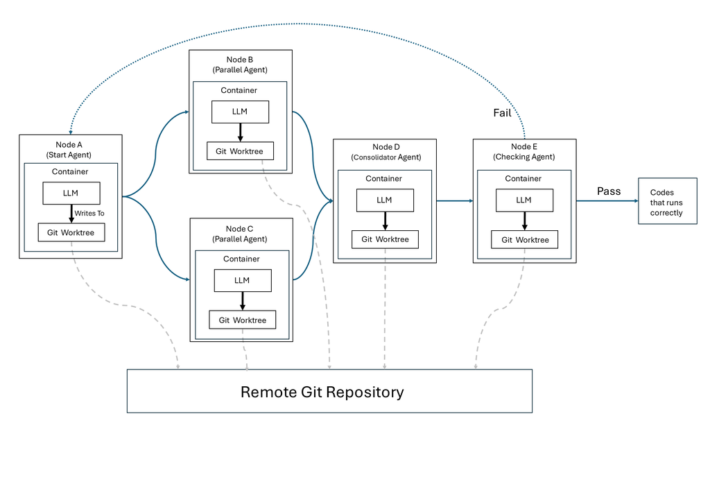

Environment Management

# 5 Timeline

## 5.1 Start-up Phase

- **Reporting Framework**: Establish a bi-weekly internal review process to track milestone progress.

## 5.2 Technical Delivery

The proposed work will be delivered over a 7-week period and involve approximately 245 hours of expert developer time. The work is structured into three phases:

- **Phase 1: Memory and State Management (Weeks 1-3)**:
  - Development of automated restart checkpointing system.
  - Development of execution caching and state retrieval system.
  - Development of agent validation and recovery system.
- **Phase 2: Environment Management (Weeks 4-6)**:
  - Development of Docker layer.
  - Integration of Git worktree with Docker.
  - Compatibility for Singularity/Apptainer.
- **Phase 3: Validation & Community Management (Week 7)**:
  - Finalization of Agents and Skills Management tools into lifecycle modules.
  - Documentation, bug fixing, and release processing.

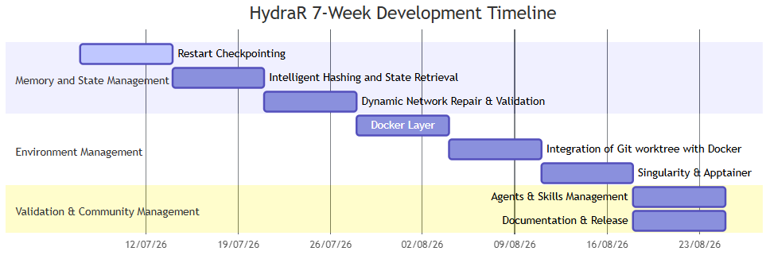

Timeline

## 5.3 Other Aspects

- **Hosting**: Code will continue to be hosted on GitHub under the `APAF-bioinformatics` organization.
- **Conference**: We will attend and present HydraR at relevant conferences to engage with the bioinformatics community.
- **Social media**: We will utilize social media to engage with the bioinformatics community.
- **Publicity**: We will share quarterly updates on the R Consortium blog.
- **Community Engagement**: An early version of the tool is already undergoing the rOpenSci peer-review process and will transition to a community-maintained model.

## 5.4 Budget & Funding Plan

- Total requested budget: **$14,400 USD**.
- This grant will solely support funding for Co-CI Tay. Co-CI Pang is currently employed by the Australian Proteome Analysis Facility (APAF) at Macquarie University and will contribute in an advisory capacity and as a user beta-tester.
- Macquarie University will provide support by providing access to High-Performance Computing (HPC) resources for testing and development.

### 5.4.1 Milestones Budget

| Description | **R Consortium** **Cash (USD)** |
| --- | --- |
| **Milestone 1: Memory and State Management** |  |
| Co-CI Tay (1.0 FTE) | $5,760 |
| **Milestone 2: Environment Management** |  |
| Co-CI Tay (1.0 FTE) | $5,760 |
| **Milestone 3: Validation & Community Management** |  |
| Co-CI Tay (1.0 FTE) | $2,880 |
| **Total** | **$14,400** |

# 6 Success

The success of the HydraR infrastructure project will be measured by its adoption, technical stability, and contribution to the R ecosystem’s AI readiness.

## 6.1 Success Metrics

- **Package Adoption**: At least 3 existing R/Bioconductor packages demonstrating “Skill Node” integration via the HydraR manifest protocol.
- **Reliability Benchmark**: A published reproducible benchmark dataset showing a >20% improvement in agent task completion rates when using HydraR state management vs. stateless alternatives.
- **Community Engagement**: Successful completion of the rOpenSci peer-review process and transition to a community-maintained model. We will seek to demonstrate the tool via online hosted by the Australian BioCommons, local workshops hosted by APAF and as submitted abstract at relevant bioinformatics conferences.
- **CRAN/Bioconductor Presence**: Maintain the 0-error/warning/note status across all major R versions.

## 6.2 Definition of Done

The project will be considered successful upon the delivery of:

- A stable CRAN-ready (or Bioconductor-ready) R package named `HydraR`.
- A fully functional memory and state management system that can autonomously retry failed tasks, skip previously executed tasks, or validate agent outputs.
- A fully functional environment memory system that integrates with Git worktree, Docker and Singularity/Apptainer.
- Comprehensive documentation, including at least three “reproducible case studies” (vignettes) showcasing traceable agent orchestration.

## 6.3 Measuring success

We will use the following markers to track our progress:

- **Week 2**: Completion of the DuckDB backend and successful hashing of R objects in a session.
- **Week 4**: Completion of agent validation and Docker layer.
- **Week 6**: Completion of integration of Git worktree with Docker and compatibility for Singularity/Apptainer
- **Week 7**: Successful community beta-test with at least 5 bioinformatics researchers and final project report and publication of the demonstration blog post on the R Consortium website.

## 6.4 Future work

HydraR is backed by **APAF Bioinformatics** (at Macquarie University), ensuring long-term institutional support and alignment with national-scale bioinformatics infrastructure (NCRIS).

- **Commercial & Institutional Support**: Ongoing maintenance is supported by funding of APAF bioinformatics staff until end of 2028. Co-CI Pang will continue to maintain the package after the grant period as part of his role at APAF.
- **Open Source Community**: By providing an interoperable manifest protocol, we encourage a “plugin” ecosystem where community members can contribute drivers and skill nodes without needing deep knowledge of the core DAG engine, ensuring the framework outlives its original funding period.

HydraR is designed to be the foundation for an “Autopoietic Agentic Ecosystem” in R, with autopoietic defined as the capacity of the system to maintain and reproduce itself. Future development directions include:

- **Decentralized Orchestration**: Extending the infrastructure to support peer-to-peer agent coordination across distributed R nodes.
- **Self-maintaining agents**: Agents that can autonomously create or remove agent nodes and to dynamically reconfigure their connections in response to the outputs of other agents.
- **Advanced Containerization**: Tighter integration with Docker/Singularity for “Secure Execution Enclaves” where agents can test code in isolated environments.
- **Agentic Benchmarking**: A standardized suite for benchmarking LLM performance on bioinformatics-specific R tasks using the HydraR traceability layer.